# NY Shooting Incidents

## Analysis of the NYPD Shooting Data Incident Dataset

This report analyses the trend of the Shooting incidents recorded by NYPD with various variables such as constituency, place of occurrence, time of day, year, location of occurrence and age group of victims and perpetrators.Finally we build a model to predict the number of shooting incidents given the time(in hour) of the day between 08:00 and 23:00. As this is a HTML document, please copy the contents of the code cells into R-Studio to reproduce the results.

### Import the tidyverse package for working with dataframes

```r
library(tidyverse)
```

### Importing the NYPD Shooting Incident Data (Historic) from its source declared as url_in

```r
url_in <- "https://data.cityofnewyork.us/api/views/833y-fsy8/rows.csv?accessType=DOWNLOAD"
nypd_data <- read_csv(url_in)
```

### Summary of the Shooting Data

```r
summary(nypd_data)
```

```
##   INCIDENT_KEY        OCCUR_DATE          OCCUR_TIME
##  Min.   :  9953245   Length:29744       Min.   :00:00:00.000000
##  1st Qu.: 67321140   Class :character   1st Qu.:03:30:45.000000
##  Median :109291972   Mode  :character   Median :15:15:00.000000
##  Mean   :133850951                      Mean   :12:46:10.874798
##  3rd Qu.:214741917                      3rd Qu.:20:44:00.000000
##  Max.   :299462478                      Max.   :23:59:00.000000
##
##      BORO           LOC_OF_OCCUR_DESC     PRECINCT      JURISDICTION_CODE
##  Length:29744       Length:29744       Min.   :  1.00   Min.   :0.0000
##  Class :character   Class :character   1st Qu.: 44.00   1st Qu.:0.0000
##  Mode  :character   Mode  :character   Median : 67.00   Median :0.0000
##                                        Mean   : 65.23   Mean   :0.3181
##                                        3rd Qu.: 81.00   3rd Qu.:0.0000
##                                        Max.   :123.00   Max.   :2.0000
##                                                         NA's   :2
##  LOC_CLASSFCTN_DESC LOCATION_DESC      STATISTICAL_MURDER_FLAG
##  Length:29744       Length:29744       Mode :logical
##  Class :character   Class :character   FALSE:23979
##  Mode  :character   Mode  :character   TRUE :5765
##
##
##
##
##  PERP_AGE_GROUP       PERP_SEX          PERP_RACE         VIC_AGE_GROUP
##  Length:29744       Length:29744       Length:29744       Length:29744
##  Class :character   Class :character   Class :character   Class :character
##  Mode  :character   Mode  :character   Mode  :character   Mode  :character
##
##
##
##
##    VIC_SEX            VIC_RACE           X_COORD_CD        Y_COORD_CD
##  Length:29744       Length:29744       Min.   : 914928   Min.   :125757
##  Class :character   Class :character   1st Qu.:1000094   1st Qu.:183042
##  Mode  :character   Mode  :character   Median :1007826   Median :195506
##                                        Mean   :1009442   Mean   :208722
##                                        3rd Qu.:1016739   3rd Qu.:239980
##                                        Max.   :1066815   Max.   :271128
##
##     Latitude       Longitude        Lon_Lat
##  Min.   :40.51   Min.   :-74.25   Length:29744
##  1st Qu.:40.67   1st Qu.:-73.94   Class :character
##  Median :40.70   Median :-73.91   Mode  :character
##  Mean   :40.74   Mean   :-73.91
##  3rd Qu.:40.83   3rd Qu.:-73.88
##  Max.   :40.91   Max.   :-73.70
##  NA's   :97      NA's   :97
```

### Cleaning up the data

1. convert Date of Occurrence from character type to Date type

```r
nypd_data <- nypd_data %>% mutate(OCCUR_DATE=mdy(OCCUR_DATE))
```

2. convert Borough(Constituency) to a factor type.

```r
nypd_data <- nypd_data %>% mutate(BORO=as_factor(BORO))
```

3. convert location of occurrence to a factor type with missing entries filled as “UNKNOWN”

```r
nypd_data <- nypd_data %>% replace_na(list(LOC_OF_OCCUR_DESC="UNKNOWN"))
nypd_data <- nypd_data %>% mutate(LOC_OF_OCCUR_DESC=as_factor(LOC_OF_OCCUR_DESC))
```

4. convert missing entries in Jurisdiction Code to “-1”

```r
nypd_data <- nypd_data %>% replace_na(list(JURISDICTION_CODE=-1))
```

5. convert location classification to a factor type with missing entries filled as “UNKNOWN”

```r
nypd_data <- nypd_data %>% replace_na(list(LOC_CLASSFCTN_DESC="UNKNOWN"))
nypd_data <- nypd_data %>% mutate(LOC_CLASSFCTN_DESC=as_factor(LOC_CLASSFCTN_DESC))
```

6. convert location description to a factor type with missing entries and “(null)” filled as “UNKNOWN”

```r
nypd_data <- nypd_data %>% replace_na(list(LOCATION_DESC="UNKNOWN"))
nypd_data <- nypd_data %>% mutate(LOCATION_DESC=case_when(LOCATION_DESC == "(null)" ~ "UNKNOWN",
                                                          .default = as.character(LOCATION_DESC)))
nypd_data <- nypd_data %>% mutate(LOCATION_DESC=as_factor(LOCATION_DESC))
```

7. convert perpetrator age group to a factor type with missing entries and “(null)” filled as “UNKNOWN”.

```r
nypd_data <- nypd_data %>% replace_na(list(PERP_AGE_GROUP="UNKNOWN"))
nypd_data <- nypd_data %>% mutate(PERP_AGE_GROUP=case_when(PERP_AGE_GROUP == "(null)" ~ "UNKNOWN",
                                                           .default = as.character(PERP_AGE_GROUP)))
nypd_data <- nypd_data %>% mutate(PERP_AGE_GROUP=as_factor(PERP_AGE_GROUP))
```

8. convert perpetrator sex to a factor type with missing entries and “(null)” filled as “UNKNOWN”

```r
nypd_data <- nypd_data %>% replace_na(list(PERP_SEX="UNKNOWN"))
nypd_data <- nypd_data %>% mutate(PERP_SEX=case_when(PERP_SEX == "(null)" ~ "UNKNOWN",
                                                     .default = as.character(PERP_SEX)))
nypd_data <- nypd_data %>% mutate(PERP_SEX=as_factor(PERP_SEX))
```

9. convert perpetrator race to a factor type with missing entries and “(null)” filled as “UNKNOWN”

```r
nypd_data <- nypd_data %>% replace_na(list(PERP_RACE="UNKNOWN"))
nypd_data <- nypd_data %>% mutate(PERP_RACE=case_when(PERP_RACE == "(null)" ~ "UNKNOWN",
                                                      .default = as.character(PERP_RACE)))
nypd_data <- nypd_data %>% mutate(PERP_RACE=as_factor(PERP_RACE))
```

10. convert victim age group to a factor type with missing entries and “(null)” filled as “UNKNOWN”.

```r
nypd_data <- nypd_data %>% replace_na(list(VIC_AGE_GROUP="UNKNOWN"))
nypd_data <- nypd_data %>% mutate(VIC_AGE_GROUP=case_when(VIC_AGE_GROUP == "(null)" ~ "UNKNOWN",
                                                           .default = as.character(VIC_AGE_GROUP)))
nypd_data <- nypd_data %>% mutate(VIC_AGE_GROUP=as_factor(VIC_AGE_GROUP))
```

11. convert victim sex to a factor type with missing entries and “(null)” filled as “UNKNOWN”

```r
nypd_data <- nypd_data %>% replace_na(list(VIC_SEX="UNKNOWN"))
nypd_data <- nypd_data %>% mutate(VIC_SEX=case_when(VIC_SEX == "(null)" ~ "UNKNOWN",
                                                     .default = as.character(VIC_SEX)))
nypd_data <- nypd_data %>% mutate(VIC_SEX=as_factor(VIC_SEX))
```

12. convert victim race to a factor type with missing entries and “(null)” filled as “UNKNOWN”

```r
nypd_data <- nypd_data %>% replace_na(list(VIC_RACE="UNKNOWN"))
nypd_data <- nypd_data %>% mutate(VIC_RACE=case_when(VIC_RACE == "(null)" ~ "UNKNOWN",
                                                     .default = as.character(VIC_RACE)))
nypd_data <- nypd_data %>% mutate(VIC_RACE=as_factor(VIC_RACE))
```

### Remove unwanted columns

```r
nypd_data <- nypd_data %>% select(OCCUR_DATE, OCCUR_TIME, BORO, LOC_OF_OCCUR_DESC, LOC_CLASSFCTN_DESC, LOCATION_DESC, PERP_AGE_GROUP, PERP_SEX, PERP_RACE, VIC_AGE_GROUP, VIC_SEX, VIC_RACE)
```

### Summary of the Shooting Data after cleaning and removing unwanted columns

```r
summary(nypd_data)
```

```
##    OCCUR_DATE           OCCUR_TIME                         BORO
##  Min.   :2006-01-01   Min.   :00:00:00.000000   BRONX        : 8834
##  1st Qu.:2009-10-29   1st Qu.:03:30:45.000000   BROOKLYN     :11685
##  Median :2014-03-25   Median :15:15:00.000000   MANHATTAN    : 3977
##  Mean   :2014-10-31   Mean   :12:46:10.874798   QUEENS       : 4426
##  3rd Qu.:2020-06-29   3rd Qu.:20:44:00.000000   STATEN ISLAND:  822
##  Max.   :2024-12-31   Max.   :23:59:00.000000
##
##  LOC_OF_OCCUR_DESC  LOC_CLASSFCTN_DESC                   LOCATION_DESC
##  UNKNOWN:25596     UNKNOWN   :25596    UNKNOWN                  :17503
##  OUTSIDE: 3466     STREET    : 2639    MULTI DWELL - PUBLIC HOUS: 5188
##  INSIDE :  682     HOUSING   :  643    MULTI DWELL - APT BUILD  : 3042
##                    DWELLING  :  341    PVT HOUSE                : 1010
##                    COMMERCIAL:  276    GROCERY/BODEGA           :  775
##                    OTHER     :   74    BAR/NIGHT CLUB           :  695
##                    (Other)   :  175    (Other)                  : 1531
##  PERP_AGE_GROUP     PERP_SEX                              PERP_RACE
##  UNKNOWN:14120   UNKNOWN:10938   UNKNOWN                       :12776
##  18-24  : 6630   M      :16845   WHITE HISPANIC                : 2667
##  25-44  : 6342   U      : 1500   BLACK                         :12323
##  <18    : 1805   F      :  461   BLACK HISPANIC                : 1487
##  45-64  :  775                   ASIAN / PACIFIC ISLANDER      :  184
##  65+    :   67                   WHITE                         :  305
##  (Other):    5                   AMERICAN INDIAN/ALASKAN NATIVE:    2
##  VIC_AGE_GROUP   VIC_SEX                             VIC_RACE
##  18-24  :10677   M:26841   BLACK                         :20999
##  25-44  :13563   F: 2891   WHITE HISPANIC                : 4511
##  <18    : 3081   U:   12   BLACK HISPANIC                : 2930
##  45-64  : 2118             ASIAN / PACIFIC ISLANDER      :  478
##  65+    :  236             WHITE                         :  741
##  UNKNOWN:   68             UNKNOWN                       :   72
##  1022   :    1             AMERICAN INDIAN/ALASKAN NATIVE:   13
```

### Visualizing shooting incidents by constituency

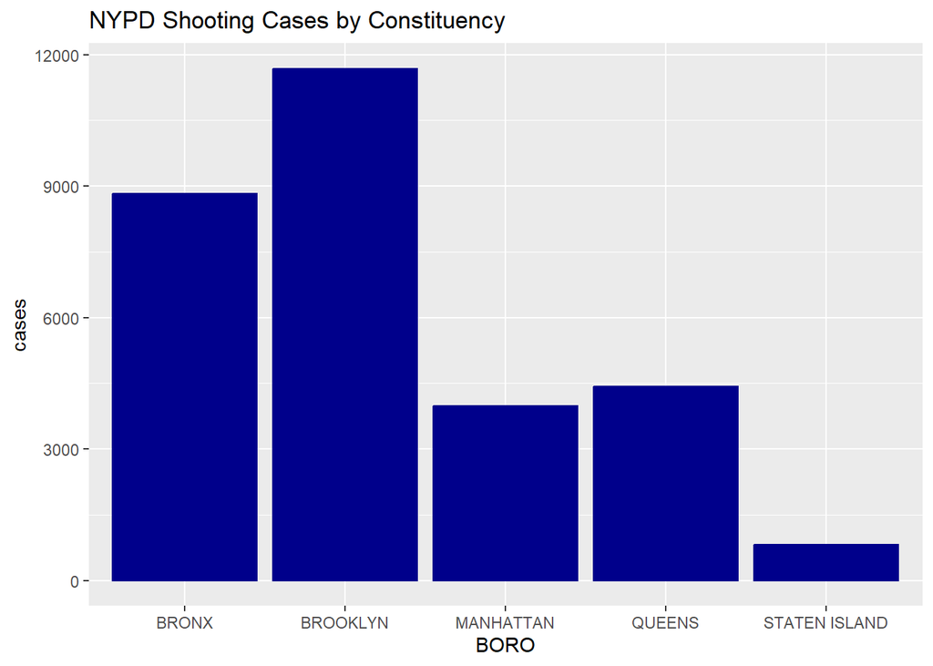

```r
shooting_by_boro <- nypd_data %>%
  mutate(case = 1) %>%
  group_by(BORO) %>%
  summarize(cases = sum(case)) %>%
  ungroup()

shooting_by_boro %>%
  ggplot(aes(x = BORO, y=cases, group = 1)) +
  geom_bar(colour = "blue4", fill = "blue4", stat = "identity") +
  labs(title = "NYPD Shooting Cases by Constituency")
```

**Analysis**: Brooklyn and Bronx seem to be the most unsafe.

### Visualizing shooting incidents by location_description

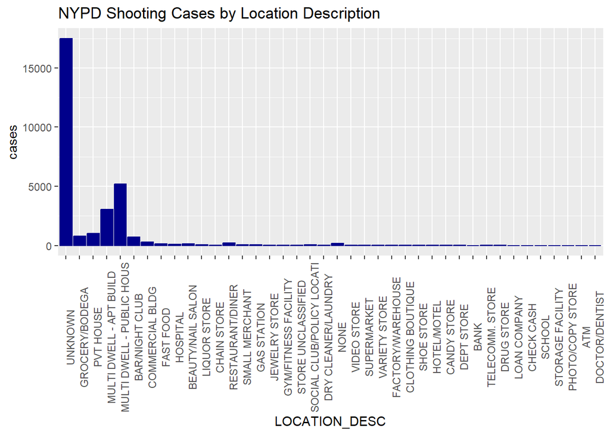

```r
shooting_by_loc_desc <- nypd_data %>%
  mutate(case = 1) %>%
  group_by(LOCATION_DESC) %>%
  summarize(cases = sum(case)) %>%
  ungroup()

shooting_by_loc_desc %>%
  ggplot(aes(x = LOCATION_DESC, y=cases, group = 1)) +
  geom_bar(colour = "blue4", fill = "blue4", stat = "identity") +
  theme(axis.text.x = element_text(angle = 90)) +
  labs(title = "NYPD Shooting Cases by Location Description")
```

**Analysis**: Are multi-dwell houses and apartments really the most unsafe areas? UNKNOWNS seem to be larger.

### Visualizing shooting incidents by year

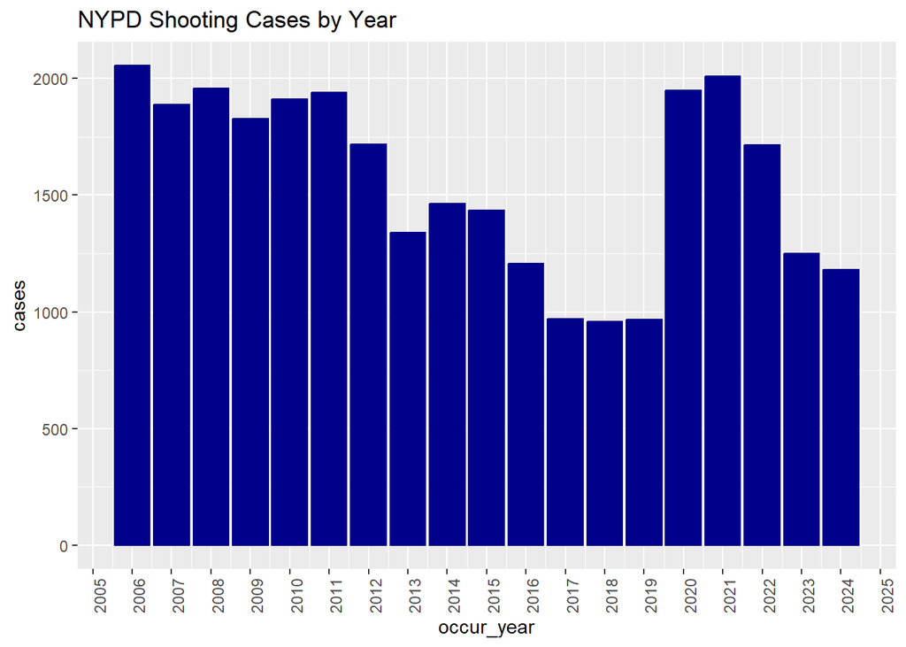

```r
shooting_by_year <- nypd_data %>%
  mutate(occur_year = year(OCCUR_DATE), case =1) %>%
  group_by(occur_year) %>%
  summarize(cases = sum(case)) %>%
  ungroup()

shooting_by_year %>%
  ggplot(aes(x = occur_year, y=cases, group = 1)) +
  geom_bar(colour = "blue4", fill = "blue4", stat = "identity") +
  theme(axis.text.x = element_text(angle = 90)) +
  scale_x_continuous(breaks = seq(2005, 2025, by=1))+
  labs(title = "NYPD Shooting Cases by Year")
```

**Analysis**: There was a sudden increase in the incidents in 2020. What was the reason? COVID?

### Visualizing shooting incidents by time of the day

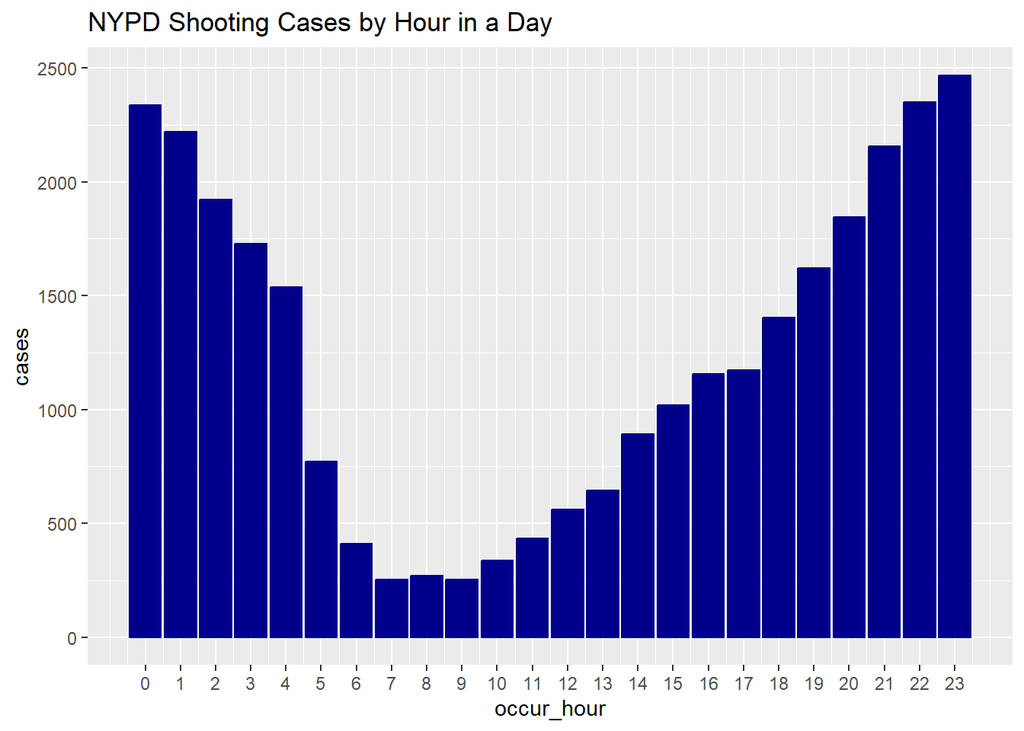

```r
shooting_by_time <- nypd_data %>%
  mutate(occur_hour = hour(OCCUR_TIME), case =1) %>%
  group_by(occur_hour) %>%
  summarize(cases = sum(case)) %>%
  ungroup()

shooting_by_time %>%
  ggplot(aes(x = occur_hour, y=cases, group = 1)) +
  geom_bar(colour = "blue4", fill = "blue4", stat = "identity") +
  theme(axis.text.x = element_text(angle = 0)) +
  scale_x_continuous(breaks = seq(0, 23, by=1)) +
  labs(title = "NYPD Shooting Cases by Hour in a Day")
```

**Analysis**: Shows that crimes at night are higher than during the day.

### Visualizing shooting incidents by perpetrator age group

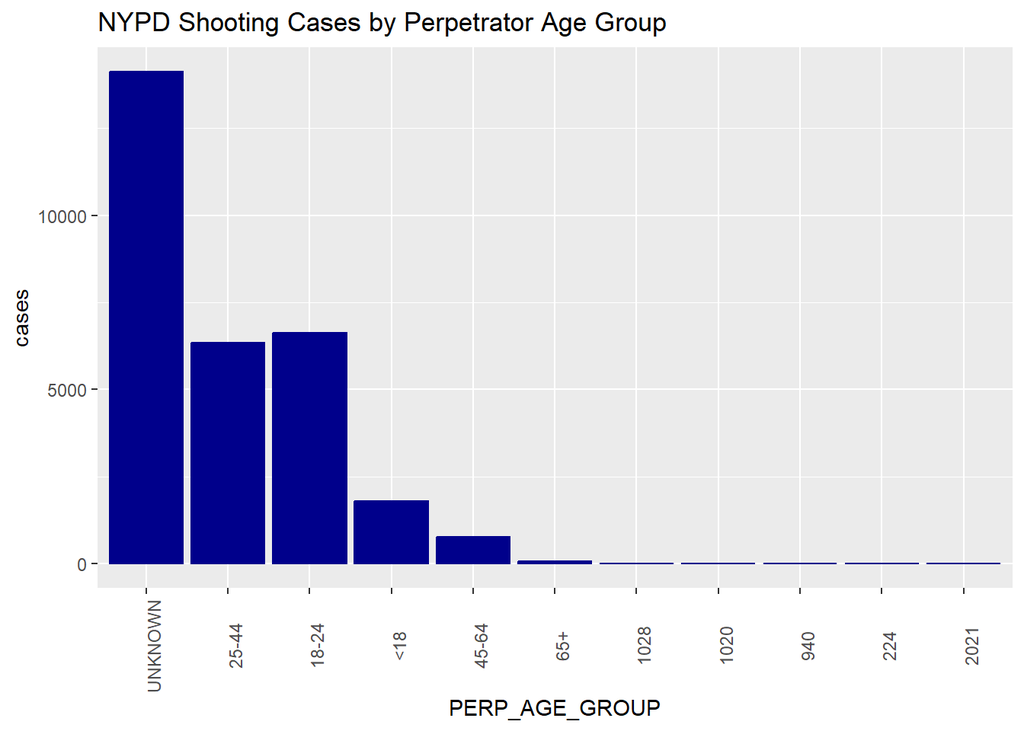

```r
shooting_by_perp_age <- nypd_data %>%
  mutate(case = 1) %>%
  group_by(PERP_AGE_GROUP) %>%
  summarize(cases = sum(case)) %>%
  ungroup()

shooting_by_perp_age %>%
  ggplot(aes(x = PERP_AGE_GROUP, y=cases, group = 1)) +
  geom_bar(colour = "blue4", fill = "blue4", stat = "identity") +
  theme(axis.text.x = element_text(angle = 90)) +
  labs(title = "NYPD Shooting Cases by Perpetrator Age Group")
```

### Visualizing shooting incidents by victim age group

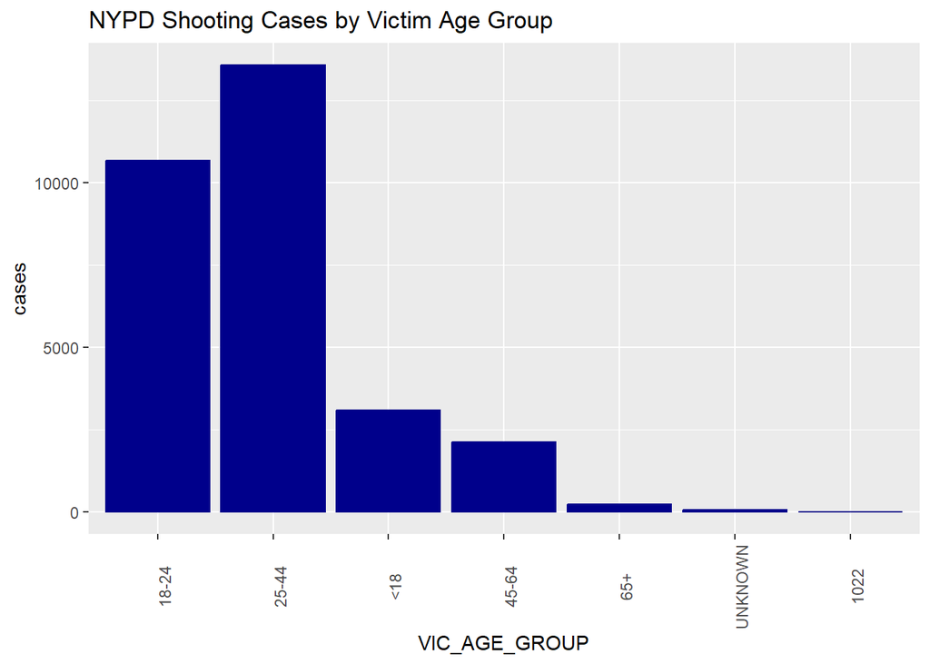

```r
shooting_by_vic_age <- nypd_data %>%
  mutate(case = 1) %>%
  group_by(VIC_AGE_GROUP) %>%
  summarize(cases = sum(case)) %>%
  ungroup()

shooting_by_vic_age %>%
  ggplot(aes(x = VIC_AGE_GROUP, y=cases, group = 1)) +
  geom_bar(colour = "blue4", fill = "blue4", stat = "identity") +
  theme(axis.text.x = element_text(angle = 90)) +
  labs(title = "NYPD Shooting Cases by Victim Age Group")
```

### Modelling a prediction of the number of crimes during the hours 8:00 to 23:00

```r
shooting_8_to_23 <- shooting_by_time %>% filter(occur_hour >= 8)
mod <- lm(cases ~ occur_hour, data = shooting_8_to_23)
```

Parameters and accuracy measurements of the model:

```r
summary(mod)
```

```
##
## Call:
## lm(formula = cases ~ occur_hour, data = shooting_8_to_23)
##
## Residuals:
##     Min      1Q  Median      3Q     Max
## -219.53  -82.12  -34.63  110.45  267.28
##
## Coefficients:
##              Estimate Std. Error t value Pr(>|t|)
## (Intercept) -1236.444    121.456  -10.18 7.48e-08 ***
## occur_hour    154.646      7.511   20.59 7.25e-12 ***
## ---
## Signif. codes:  0 '***' 0.001 '**' 0.01 '*' 0.05 '.' 0.1 ' ' 1
##
## Residual standard error: 138.5 on 14 degrees of freedom
## Multiple R-squared:  0.968,  Adjusted R-squared:  0.9657
## F-statistic: 423.9 on 1 and 14 DF,  p-value: 7.249e-12
```

Visualizing the predictions of the model:

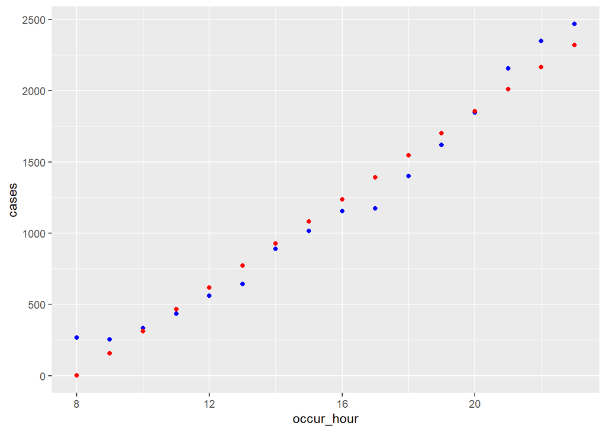

```r
shooting_by_time_pred <- shooting_8_to_23 %>% mutate(pred = predict(mod))
shooting_by_time_pred %>% ggplot() +
  geom_point(aes(x = occur_hour, y = cases), color = "blue") +
  geom_point(aes(x = occur_hour, y = pred), color = "red")
```

**Analysis**: Model tends to predict the number of crimes given the hour of the day between 08:00 and 23:00 very well.

### Conclusion

1. Brooklyn in the constituency with the highest number of shooting incidents at least according to the data. However it is not clear if the data is exhaustive and covers all incidents in other Boroughs as well. There may be places where crimes are reported more often than others.
2. People in Multi-Dwelling apartments and houses have a high risk of shooting crimes compared to other places. There may be a personal bias in this analysis as there tends to be a big gathering of people in such places who know each other and may have conflicting relationships. The UNKNOWN category is quite large in comparison. Hence more verification of the data is required.
3. People of age 18-44 commit and are victims of most of the shooting incidents. However the large amount of unknown age groups of perpetrators may change the results if more clarification is achieved.
4. Crimes at night times are higher compared to day time.
5. There was a sudden increase in the incidents in the year 2020. A possible explanation could be the excessive restrictions implemented during Covid-19 breakout that affected mental health of many. However this could just be my personal bias as that was the most famous incident of that year. More analysis of the data, such as source of the data, sampling of the data, related variables need to be analysed to prevent this bias.
6. From the summary of the data we see that males are more prone to commit and be victim of shooting than the other genders.